# Compte rendu TP2 - Régression linéaire, probabilités, intervalle de confiance

# Calculs de probabilité

## Nous allons maintenant travailler sur les calculs basés sur des données. L’analyse porte sur la taille des arbres sequoia.

```r
data_sequoia = read.table(params$fichier_sequoia , sep = params$separateur_sequoia , header = TRUE)

names(data_sequoia)
```

```
## [1] "taille_arbre"
```

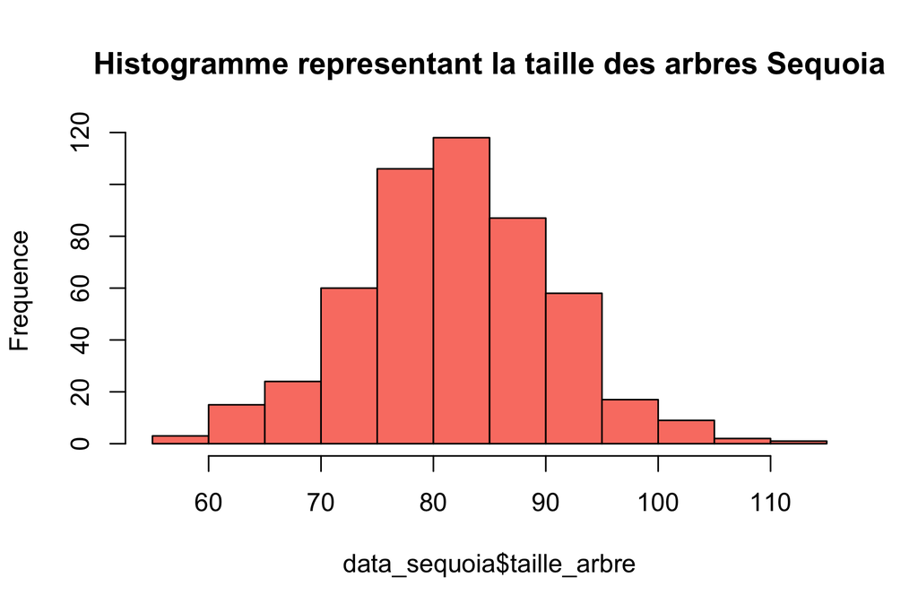

```r
hist(data_sequoia$taille_arbre,
     main="Histogramme representant la taille des arbres Sequoia",
     ylab='Frequence',
     col='salmon' )
```

```r
mean_taille_sequoia = mean(data_sequoia$taille_arbre)
ecart_type_sequoia = sd(data_sequoia$taille_arbre)

cat("La taille moyenne est de" , mean_taille_sequoia , " et l'écart-type est" , ecart_type_sequoia
    )
```

```
## La taille moyenne est de 82.268  et l'écart-type est 8.746037
```

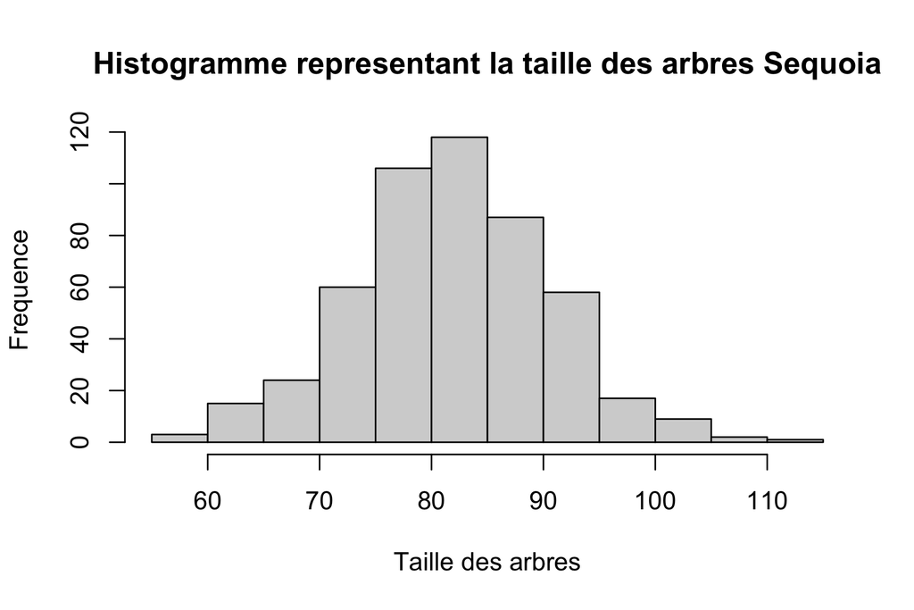

```r
histogramme_taille_arbre = function() { hist(data_sequoia$taille_arbre , main="Histogramme representant la taille des arbres Sequoia" , ylab='Frequence' , xlab='Taille des arbres' ) }

histogramme_taille_arbre()
```

```r
outfile_seq = here("figure_tp2" , "histogramme_taille_arbre.jpg")
jpeg(outfile_seq)
histogramme_taille_arbre()
dev.off()
```

```r
if ( file.exists(outfile_seq)) {
  cat("Le fichier a bien ete genérée.
      " , outfile_seq )
  } # Utilisation de if pour envoyer un output qui confirme l'existence de notre fichier.
```

```
## Le fichier a bien ete genérée.
##        /Users/bachri/Documents/M1_BBS/S7/tdb/tp_tdb/figure_tp2/histogramme_taille_arbre.jpg
```

```r
## Quel est la probabilité qu'un arbre mesure 80 m ?


proba_arbre_80m = length(which(data_sequoia$taille_arbre==80))/length(data_sequoia$taille_arbre)

cat("La probabilité qu'un arbre mesure 80m est de", proba_arbre_80m)
```

```
## La probabilité qu'un arbre mesure 80m est de 0.044
```

```r
## Quel est la probabilité qu'un arbre mesure 100 m ?


proba_arbre_100m = length(data_sequoia$taille_arbre[data_sequoia$taille_arbre>100])/length(data_sequoia$taille_arbre)

cat("La probabilité qu'un arbre mesure 100m est de", proba_arbre_100m)
```

```
## La probabilité qu'un arbre mesure 100m est de 0.024
```

```r
## Calcul basés sur une loi centrée réduite N(0,1)


dnorm(0,0,1) # On a ici x=0, mean=0 et sd=1 respectivement. Ici , x est une variable aleatoire, mean correspond à la mean de la population et sd c'est l'ecart type de la popualtion.
```

```
## [1] 0.3989423
```

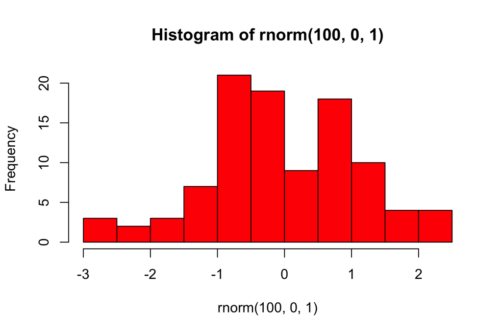

```r
hist(rnorm(100,0,1), col='red')
```

```r
# En augmentant n, on va tendre vers une figure de plus en plus symetrique centrée normale.
pnorm(0,0,1)
```

```
## [1] 0.5
```

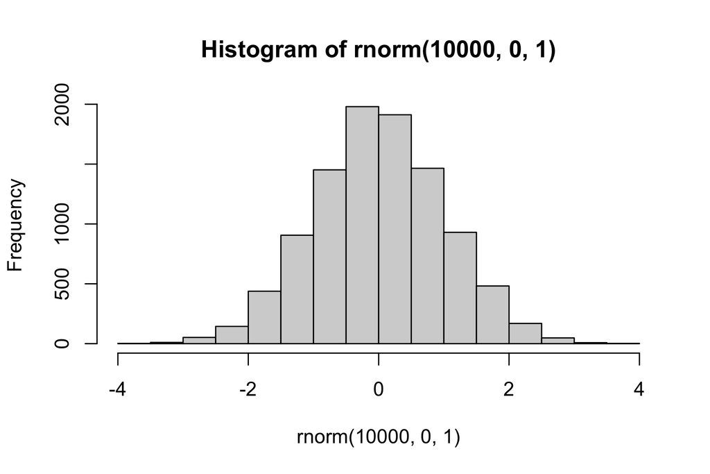

```r
hist(rnorm(10000,0,1))
```

```r
# On va calculer la mean et écart type des tailles des séquoia pour calculer la probabilité qu'u arbre mesure 80m.


calcul_arbre80m = round(dnorm(80,mean_taille_sequoia , ecart_type_sequoia ) , 3)
calcul_arbre80m
```

```
## [1] 0.044
```

```r
calcul_arbre100m = round(pnorm(100,mean_taille_sequoia, ecart_type_sequoia, lower.tail = FALSE),3)
calcul_arbre100m
```

```
## [1] 0.021
```

L’option lower.tail = F est utilisé pour trouver la valeur que la probabilité de la variable aleatoire normal soit inferieur ou superieure a q. lower.tail= TRUE pour valeurs inferieurs. Par défaut, lower.tail=TRUE

Ici, il faut utiliser pnorm pour avoir la somme des probabilités des arbres qui font plus de 100m. Cumulative.

```
## La probabilité qu'un arbre fasse 80m selon la loi normal est de 0.044
```

```
## Le calcul des probabilités qu'un arbre mesure 100m ou plus est de 0.021 . Cette valeur est legerement differente que le calcul direct par nombre d'arbres de 100m divisé par le total. 0.024 vs 0.021
```

Ces differences sont du à l’échantillonage donc on aura toujours une différence.

# Calculs basés sur une loi binomaile B(n,p)

```r
n=100
p=0.8
proba_80_graines_germent = dbinom(80,n,prob=p)
proba_au_max80_graines_germent = pbinom(80,n,prob=p)
proba_plus_de_80_graines_germent = pbinom(80,n,prob=p , lower.tail=F)
cat("La probabilité que 80 graines germent est de" ,proba_80_graines_germent)
```

```
## La probabilité que 80 graines germent est de 0.09930021
```

```
## La probabilité que au maximum 80 graines germent est de 0.5398386
```

```
## La probabilité que plus de 80 graines germent est de 0.4601614
```

```
## D'apres notre n et p, on devrait s'attendre en mean a 80
```

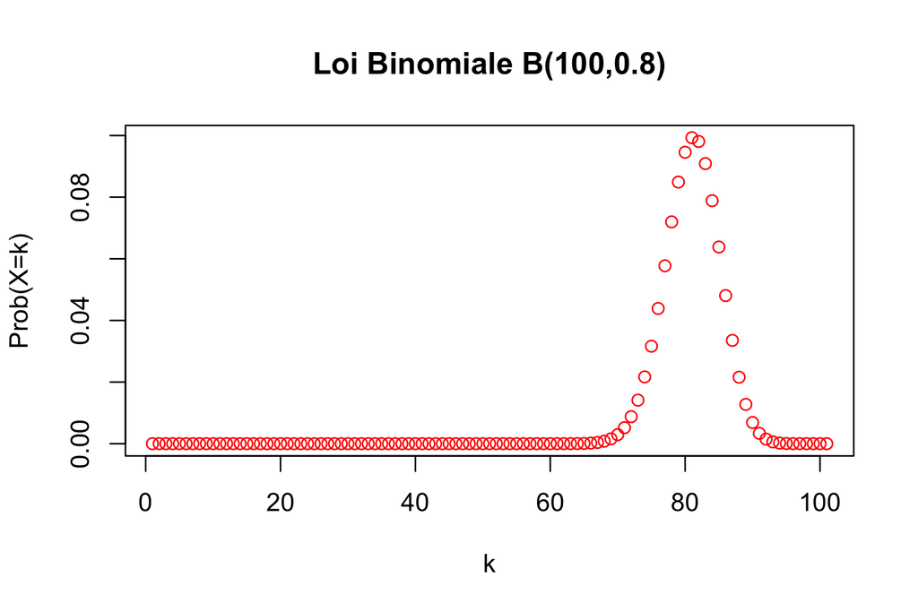

```
## Le fichier a bien ete genérée.  /Users/bachri/Documents/M1_BBS/S7/tdb/tp_tdb/figure_tp2/figure_loi_binomiale.jpg
```

On aura ici des points et pas une droite car la loi binomiale est une loi discrete et non continue.

# Estimer un intervalle de confiance (IC) d’un paramètre populationnel (µ, p,…) à partir d’un échantillon

```r
data_tomatos = read.table(params$fichier_tomatos , sep = params$separateur_tomatos , header=T)
names(data_tomatos)
```

```
## [1] "poids_tomate"
```

```r
mean_tomatos = mean(data_tomatos$poids_tomate)
sd_tomatos = sd(data_tomatos$poids_tomate)
n_tomatos = length(data_tomatos$poids_tomate)


# Intervalle de confiance de la mean théorique µ de la popualtion, à partir de la mean m calculé sur un échantillon.
# Intervalle de confiance a 95%

error = qt(0.975, df=n_tomatos-1)*sd_tomatos/sqrt(n_tomatos)
left = mean_tomatos - error
right = mean_tomatos + error
left;right
```

```
## [1] 11.82531
```

```
## [1] 12.41069
```

```
## L'intervalle de confiance a 95% sera compris entre 11.82531 et 12.41069 . On peut estimer que la mean de la taille des tomatos de la population se trouve dans cette intervalle ave cun risque d'erreur de 5%.
```

On peut augmenter l’intervalle de confiance mais on aura des valeurs plus importantes.

```r
error_99 = qt(0.995, df=n_tomatos-1)*sd_tomatos/sqrt(n_tomatos)
left_99_tomatos = mean_tomatos - error_99
right_99_tomatos = mean_tomatos + error_99
left_99_tomatos;right_99_tomatos
```

```
## [1] 11.72767
```

```
## [1] 12.50833
```

[output not shown]

Cet intervalle pourra etre plus petite en augmentant notre nombre de tomatos.

```r
frequence_red_apples = 0.4 # fréquence de pommes rouges dans l'échantillon
n = 125 # taille de l'échantillon

error_red_apple = qnorm(0.975)*sqrt(frequence_red_apples*(1-frequence_red_apples)/n)

left_apples = frequence_red_apples - error_red_apple
right_apples = frequence_red_apples + error_red_apple
left_apples;right_apples
```

```
## [1] 0.3141187
```

```
## [1] 0.4858813
```

```r
cat("L'intervalle ayant 95% de chance d'obtenir la vrai proportion p de la popualtion est entre" , left_apples, "et",  right_apples)
```

```
## L'intervalle ayant 95% de chance d'obtenir la vrai proportion p de la popualtion est entre 0.3141187 et 0.4858813
```

## Sources utiles

- https://www.datamentor.io/r-programming/if-else-statement (if else/)
- https://www.rdocumentation.org/packages/base/versions/3.6.2/topics/sprintf (sprintf)
- [https://stat.ethz.ch/R-manual/R-devel/library/base/html/sprintf.html] (https://stat.ethz.ch/R-manual/R-devel/library/base/html/sprintf.html) (sprintf)
- https://yihui.org/knitr/options/ (Options knitr)